# **Stock Price Prediction Project using LSTM and RNN**

## **Project Overview**

Stock price prediction holds a crucial role in financial markets, carrying substantial implications for businesses, investors, and financial institutions. Accurate forecasts help investors and fund managers make well-informed investment decisions, identifying opportunities for maximizing profits or minimizing losses. This, in turn, allows them to wisely allocate capital and adjust investment portfolios based on predicted price movements.

The integration of Machine Learning (ML) and Deep Learning has proven to enhance stock price prediction accuracy, aiding investors, traders, and financial analysts in their decision-making process. ML techniques provide valuable insights, optimize investment strategies, and enhance risk management in the dynamic and complex realm of the stock market.

However, predicting stock prices remains a challenging task due to the inherent complexity and volatility of financial markets. Traditional methods often fall short in capturing the intricate patterns and dependencies present in stock price data. In contrast, RNN and LSTM models demonstrate promise in effectively capturing temporal dependencies and making accurate predictions in various time series forecasting tasks.

In the initial project of our four-part series, our focus will be on implementing recurrent neural networks (RNNs) and long short-term memory (LSTM) networks, specifically for stock price prediction. This project serves as a fundamental stepping stone, allowing us to grasp and utilize these advanced deep learning techniques in the context of financial forecasting.

Throughout the project, we will delve into the fundamentals of RNNs and LSTMs, exploring their suitability in capturing temporal dependencies within stock price data. Additionally, we will learn the necessary preprocessing steps to prepare historical stock price datasets for training and testing our models.

## **Import Libraries**

```python
import warnings
warnings.filterwarnings("ignore")
```

```python
from datetime import datetime
import tensorflow as tf
import numpy as np
import pandas as pd
import matplotlib.pyplot as plt
import seaborn as sns
import keras
import yfinance as yf
from pandas_datareader.data import DataReader
from pandas_datareader import data as pdr
from sklearn.metrics import mean_squared_error
from sklearn.preprocessing import MinMaxScaler
import pandas_ta as ta
from keras.layers import LSTM, SimpleRNN, Dense
from keras.models import Sequential
```

```python
keras.backend.set_image_data_format("channels_last")
sns.set_style("whitegrid")
plt.style.use("fivethirtyeight")
yf.pdr_override()
%matplotlib inline
```

## **Time Series Data**

### Loading data

```python
dataset = pdr.get_data_yahoo('AAPL', start='2012-01-01', end=datetime.now())
```

```
[*********************100%***********************]  1 of 1 completed
```

```python
dataset.head()
```

| Date | Open | High | Low | Close | Adj Close | Volume |
| --- | --- | --- | --- | --- | --- | --- |
| 2012-01-03 | 14.621429 | 14.732143 | 14.607143 | 14.686786 | 12.482924 | 302220800 |
| 2012-01-04 | 14.642857 | 14.810000 | 14.617143 | 14.765714 | 12.550011 | 260022000 |
| 2012-01-05 | 14.819643 | 14.948214 | 14.738214 | 14.929643 | 12.689342 | 271269600 |
| 2012-01-06 | 14.991786 | 15.098214 | 14.972143 | 15.085714 | 12.821994 | 318292800 |
| 2012-01-09 | 15.196429 | 15.276786 | 15.048214 | 15.061786 | 12.801659 | 394024400 |

### Plotting training and test data

```python
tstart=2016
tend=2020
```

```python
def train_test_plot(dataset, tstart, tend):
    dataset.loc[f"{tstart}":f"{tend}", "High"].plot(figsize=(16, 4), legend=True)
    dataset.loc[f"{tend + 1}":, "High"].plot(figsize=(16, 4), legend=True)
    plt.legend([f"Train (Before {tend+1})", f"Test ({tend+1} and beyond)"])
    plt.title("Apple stock price")
    plt.show()
```

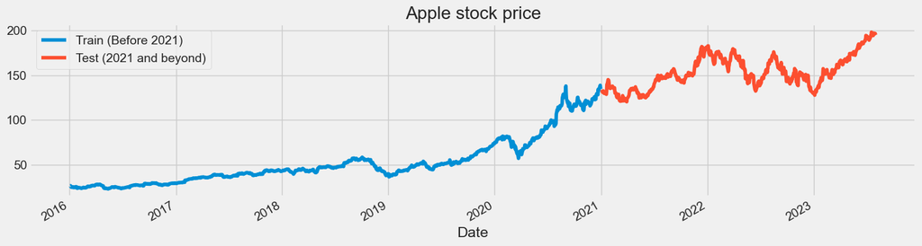

```python
train_test_plot(dataset, tstart, tend)
```

### Creating train and test datasets

```python
def train_test_split(dataset, tstart, tend, columns=["High"]):
    train = dataset.loc[f"{tstart}":f"{tend}", columns].values
    test = dataset.loc[f"{tend+1}":, columns].values
    return train, test
```

```python
training_set, test_set = train_test_split(dataset, tstart, tend)
```

### Scaling dataset values

```python
sc = MinMaxScaler(feature_range=(0, 1))
training_set = training_set.reshape(-1, 1)
training_set_scaled = sc.fit_transform(training_set)
```

### Creating overlapping window batches

```python
n_steps = 1
features = 1
```

```python
def split_sequence(sequence, n_steps):
    X, y = list(), list()
    for i in range(len(sequence)):
        end_ix = i + n_steps
        if end_ix > len(sequence) - 1:
            break
        seq_X, seq_y = sequence[i:end_ix], sequence[end_ix]
        X.append(seq_X)
        y.append(seq_y)
    return np.array(X), np.array(y)
```

```python
X_train, y_train = split_sequence(training_set_scaled, n_steps)
```

```python
X_train = X_train.reshape(X_train.shape[0], X_train.shape[1], features)
```

### Evaluation

```python
def plot_predictions(test, predicted, title):
    plt.plot(test, color="gray", label="Real")
    plt.plot(predicted, color="red", label="Predicted")
    plt.title(f'{title}')
    plt.xlabel("Time")
    plt.ylabel(f'{title}')
    plt.legend()
    plt.show()
```

```python
def return_rmse(test, predicted):
    rmse = np.sqrt(mean_squared_error(test, predicted))
    print("The root mean squared error is {:.2f}.".format(rmse))
```

```python
def plot_loss(history):
    plt.figure(figsize=(15, 7))
    plt.plot(history.history["loss"], label="loss")
    plt.legend(loc="best")
    plt.show()
```

```python
model_rnn = Sequential()
model_rnn.add(SimpleRNN(units=125, input_shape=(n_steps, features)))
model_rnn.add(Dense(units=1))
```

```python
model_rnn.compile(optimizer="RMSprop", loss="mse")
```

```python
history = model_rnn.fit(X_train, y_train, epochs=10, batch_size=32)
```

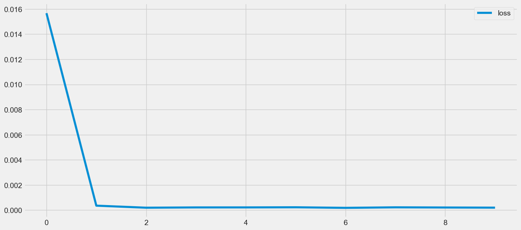

```python
plot_loss(history)
```

## **Time Series Prediction**

One approach to time series prediction involves using a complete test set, where we extract a historical window and forecast a future data point. However, this method may not be practical when trying to predict a larger future window. For instance, in stock prediction, we aim to forecast the price of a specific share over several days or weeks.

In such cases, we require sequence generation, which involves leveraging previously predicted values within our sliding window. Nevertheless, this approach can lead to considerable noise accumulation since predictions are not flawless.

```python
inputs = sc.transform(test_set.reshape(-1, 1))
```

```python
X_test, y_test = split_sequence(inputs, n_steps)
X_test = X_test.reshape(-1, n_steps, features)
```

```python
predicted_stock_price = model_rnn.predict(X_test)
predicted_stock_price = sc.inverse_transform(predicted_stock_price)
```

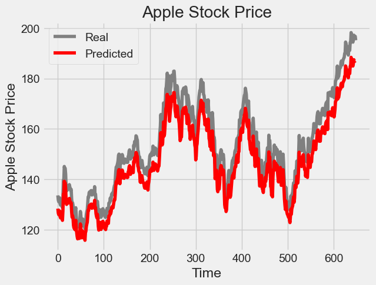

```python
plot_predictions(test_set, predicted_stock_price, "Apple Stock Price")
```

### Sequence Generation

```python
steps_in_future = 25
```

```python
def sequence_generation(dataset, sc, model, steps_future):
    high_dataset = dataset.iloc[len(dataset)-len(test_set)-n_steps:]["High"]
    high_dataset = sc.transform(high_dataset.values.reshape(-1, 1))
    inputs = high_dataset[:n_steps]

    for _ in range(steps_future):
        curr_pred = model.predict(inputs[-n_steps:].reshape(-1, n_steps, features), verbose=0)
        inputs = np.append(inputs, curr_pred, axis=0)

    return sc.inverse_transform(inputs[n_steps:])
```

```python
results = sequence_generation(dataset, sc, model_rnn, steps_in_future)
```

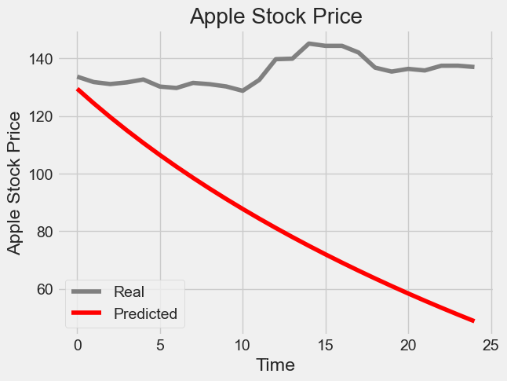

```python
plot_predictions(test_set[:steps_in_future], results, "Apple Stock Price")
```

## **LSTM**

```python
model_lstm = Sequential()
model_lstm.add(LSTM(units=125, input_shape=(n_steps, features)))
model_lstm.add(Dense(units=1))
```

```python
model_lstm.compile(optimizer="RMSprop", loss="mse")
```

```python
history = model_lstm.fit(X_train, y_train, epochs=10, batch_size=32)
```

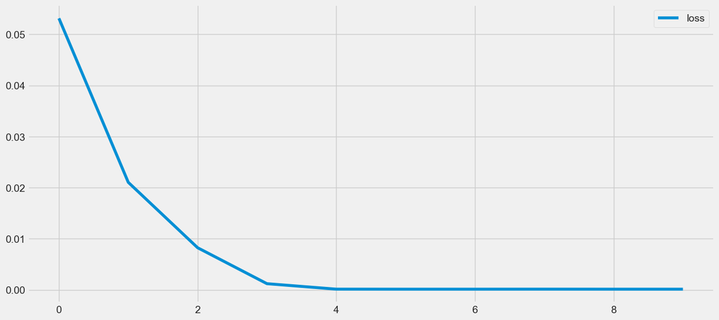

```python
plot_loss(history)
```

```python
predicted_stock_price = model_lstm.predict(X_test)
predicted_stock_price = sc.inverse_transform(predicted_stock_price)
```

### Time Series Prediction: LSTM

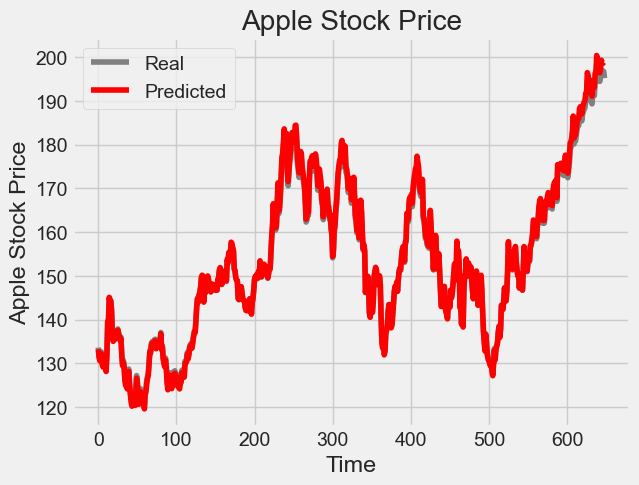

```python
plot_predictions(test_set, predicted_stock_price, "Apple Stock Price")
```

### Sequence Generation: LSTM

```python
results = sequence_generation(dataset, sc, model_lstm, steps_in_future)
```

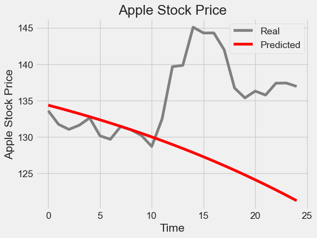

```python
plot_predictions(test_set[:steps_in_future], results, "Apple Stock Price")
```

## Multivariate Input

```python
multi_variate_df = dataset.copy()
```

### Creating Technical Indicators

**Relative Strength Index (RSI)**: The relative strength index (RSI) is a technical analysis momentum indicator that assesses the velocity and scale of recent price changes in a security. Its primary purpose is to determine whether the price of a security is currently overvalued or undervalued.

**Exponential Moving Average (EMA)**: The exponential moving average (EMA) is a variant of the moving average (MA) used in technical analysis. It assigns more significance to the most recent data points, making it react more dynamically to recent price changes compared to the simple moving average (SMA). Traders often utilize different EMA lengths, such as 10-day, 50-day, and 200-day moving averages, to analyze price trends effectively.

```python
multi_variate_df['RSI'] = ta.rsi(multi_variate_df.Close, length=15)
multi_variate_df['EMAF'] = ta.ema(multi_variate_df.Close, length=20)
multi_variate_df['EMAM'] = ta.ema(multi_variate_df.Close, length=100)
multi_variate_df['EMAS'] = ta.ema(multi_variate_df.Close, length=150)
```

### Creating Labels

```python
multi_variate_df['Target'] = multi_variate_df['Adj Close'] - dataset.Open
multi_variate_df['Target'] = multi_variate_df['Target'].shift(-1)
multi_variate_df.dropna(inplace=True)
multi_variate_df.drop(['Volume', 'Close'], axis=1, inplace=True)
```

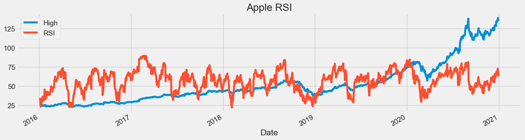

```python
multi_variate_df.loc[f"{tstart}":f"{tend}", ["High", "RSI"]].plot(figsize=(16, 4), legend=True)
plt.title("Apple RSI")
plt.show()
```

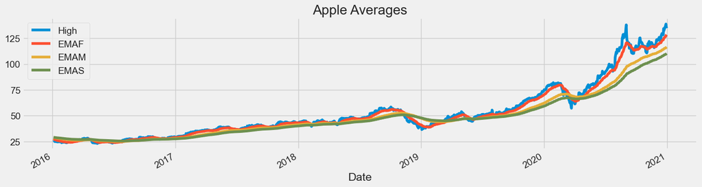

```python
multi_variate_df.loc[f"{tstart}":f"{tend}", ['High', 'EMAF', 'EMAM', 'EMAS']].plot(figsize=(16, 4), legend=True)
plt.title("Apple Averages")
plt.show()
```

```python
feat_columns = ['Open', 'High', 'RSI', 'EMAF', 'EMAM', 'EMAS']
label_col = ['Target']
```

### Splitting train and test data

```python
mv_training_set, mv_test_set = train_test_split(multi_variate_df, tstart, tend, feat_columns + label_col)
```

```python
X_train = mv_training_set[:, :-1]
y_train = mv_training_set[:, -1]

X_test = mv_test_set[:, :-1]
y_test = mv_test_set[:, -1]
```

### Scaling Data

```python
X_train = sc.fit_transform(X_train).reshape(-1, 1, mv_features)
X_test = sc.transform(X_test).reshape(-1, 1, mv_features)
```

### Model

```python
model_mv = Sequential()
model_mv.add(LSTM(units=125, input_shape=(1, mv_features)))
model_mv.add(Dense(units=1))

model_mv.compile(optimizer="RMSprop", loss="mse")
```

```python
history = model_mv.fit(X_train, y_train, batch_size=32, epochs=20)
```

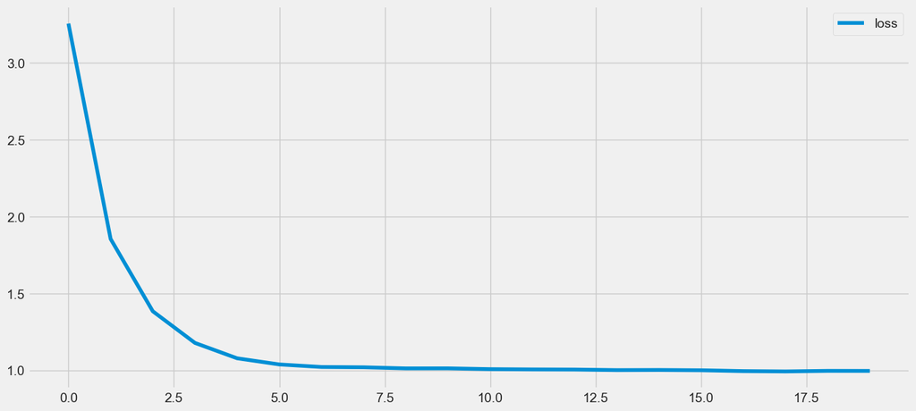

```python
plot_loss(history)
```

### Results

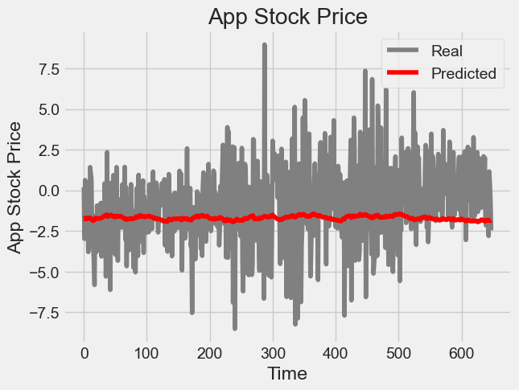

```python
predictions = model_mv.predict(X_test)
plot_predictions(y_test, predictions, "App Stock Price")
```

## **Conclusion**

In this project, we delved into the application of Recurrent Neural Networks (RNNs) and Long Short-Term Memory (LSTM) models for stock price prediction. Our approach was systematic, encompassing the understanding of fundamental concepts, data preprocessing, model development, and performance evaluation.

Throughout the project, we acquired valuable insights into the intricacies and difficulties associated with forecasting stock prices. We mastered the art of preprocessing time series data, constructing neural network models, and assessing their effectiveness. This project serves as a foundation for further exploration and experimentation in the domain of stock price prediction utilizing RNNs and LSTMs.